# 项目背景

1912年泰坦尼克号邮轮在其处女启航时触礁冰山而沉没，造成大部分乘客和船员死亡。而这个项目，我们将探讨泰坦尼克号上 2224 名乘客和船员中的891 名乘客的人口学数据和基本信息，以确定乘客的生还与哪些因素有关。

变量定义： PassengerId乘客序号； Survived生还 0=否，1=是； Pclass船舱等级 1 =高级，2 = 中级，3 = 普通； Name乘客姓名； Sex性别 Female=女性 Male=男性； Age年龄； Sibsp 0=未带兄弟姐妹/配偶 1=兄弟姐妹/配偶； Parch 0=未带父母/孩子 1=父母/孩子； Ticket船票号码； Fare票价； Cabin客舱客舱号码； Embarked登船港口 C=瑟堡，Q=皇后镇，S=南安普敦。

# 问题

探讨乘客生还率与Pclass、Sex、Age、SibSp、Parch、Fare、Cabin、Embarked的关系

# 导入数据集

```python
import pandas as pd
import numpy as np
%matplotlib inline
import matplotlib.pyplot as plt
import seaborn as sns
titanic=pd.read_csv('titanic-data.csv')
```

```python
titanic.head(5)
```

|  | PassengerId | Survived | Pclass | Name | Sex | Age | SibSp | Parch | Ticket | Fare | Cabin | Embarked |
| --- | --- | --- | --- | --- | --- | --- | --- | --- | --- | --- | --- | --- |
| 0 | 1 | 0 | 3 | Braund, Mr. Owen Harris | male | 22.0 | 1 | 0 | A/5 21171 | 7.2500 | NaN | S |
| 1 | 2 | 1 | 1 | Cumings, Mrs. John Bradley (Florence Briggs Th... | female | 38.0 | 1 | 0 | PC 17599 | 71.2833 | C85 | C |
| 2 | 3 | 1 | 3 | Heikkinen, Miss. Laina | female | 26.0 | 0 | 0 | STON/O2. 3101282 | 7.9250 | NaN | S |
| 3 | 4 | 1 | 1 | Futrelle, Mrs. Jacques Heath (Lily May Peel) | female | 35.0 | 1 | 0 | 113803 | 53.1000 | C123 | S |
| 4 | 5 | 0 | 3 | Allen, Mr. William Henry | male | 35.0 | 0 | 0 | 373450 | 8.0500 | NaN | S |

## 重复数据

```python
titanic.duplicated().value_counts()
```

```
False    891
dtype: int64
```

可以看出数据集没有重复数据

## 描述性分析

```python
titanic.describe()
```

|  | PassengerId | Survived | Pclass | Age | SibSp | Parch | Fare |
| --- | --- | --- | --- | --- | --- | --- | --- |
| count | 891.000000 | 891.000000 | 891.000000 | 714.000000 | 891.000000 | 891.000000 | 891.000000 |
| mean | 446.000000 | 0.383838 | 2.308642 | 29.699118 | 0.523008 | 0.381594 | 32.204208 |
| std | 257.353842 | 0.486592 | 0.836071 | 14.526497 | 1.102743 | 0.806057 | 49.693429 |
| min | 1.000000 | 0.000000 | 1.000000 | 0.420000 | 0.000000 | 0.000000 | 0.000000 |
| 25% | 223.500000 | 0.000000 | 2.000000 | 20.125000 | 0.000000 | 0.000000 | 7.910400 |
| 50% | 446.000000 | 0.000000 | 3.000000 | 28.000000 | 0.000000 | 0.000000 | 14.454200 |
| 75% | 668.500000 | 1.000000 | 3.000000 | 38.000000 | 1.000000 | 0.000000 | 31.000000 |
| max | 891.000000 | 1.000000 | 3.000000 | 80.000000 | 8.000000 | 6.000000 | 512.329200 |

上表可以看出891名乘客整体幸存率只为38.4%，在这891名乘客中最大年龄为80岁，最小年龄不到一岁，平均年龄达到30岁。 随行人员中，多至8个兄弟姐妹及配偶一起出行，少至一人，但整体的平均率只在0.5个；父母孩子的携带数也多至6人，少的就是独自一人，但整体的平均率也只在0.4个左右。 乘客这趟旅行平均花费为32美元，最高花费可达512美元

## 缺失值

```python
titanic.info()
```

```
<class 'pandas.core.frame.DataFrame'>
RangeIndex: 891 entries, 0 to 890
Data columns (total 12 columns):
PassengerId    891 non-null int64
Survived       891 non-null int64
Pclass         891 non-null int64
Name           891 non-null object
Sex            891 non-null object
Age            714 non-null float64
SibSp          891 non-null int64
Parch          891 non-null int64
Ticket         891 non-null object
Fare           891 non-null float64
Cabin          204 non-null object
Embarked       889 non-null object
dtypes: float64(2), int64(5), object(5)
memory usage: 66.2+ KB
```

可以看出Age、Cabin、Embarked列有缺失值,后面将要进行缺失值处理

# 数据清理

## 删除无用的数据

```python
titanic_df=titanic.drop(['PassengerId','Ticket','Name'],axis='columns')
```

```python
titanic_df.head()
```

|  | Survived | Pclass | Sex | Age | SibSp | Parch | Fare | Cabin | Embarked |
| --- | --- | --- | --- | --- | --- | --- | --- | --- | --- |
| 0 | 0 | 3 | male | 22.0 | 1 | 0 | 7.2500 | NaN | S |
| 1 | 1 | 1 | female | 38.0 | 1 | 0 | 71.2833 | C85 | C |
| 2 | 1 | 3 | female | 26.0 | 0 | 0 | 7.9250 | NaN | S |
| 3 | 1 | 1 | female | 35.0 | 1 | 0 | 53.1000 | C123 | S |
| 4 | 0 | 3 | male | 35.0 | 0 | 0 | 8.0500 | NaN | S |

## 缺失值处理

Age缺失值用平均值填补； Embarked缺失值用众数填补,因为众数可能有多个，故先求得众数； Cabin缺失值太多，分析没有太多意义，故后面不对这列进行分析

```python
titanic_df['Age']=titanic_df['Age'].fillna(titanic_df['Age'].mean())
print titanic_df['Embarked'].mode()
titanic_df['Embarked']=titanic_df['Embarked'].fillna(titanic_df['Embarked'].mode())
```

```
0    S
dtype: object
```

```python
titanic_df.describe()
```

|  | Survived | Pclass | Age | SibSp | Parch | Fare |
| --- | --- | --- | --- | --- | --- | --- |
| count | 891.000000 | 891.000000 | 891.000000 | 891.000000 | 891.000000 | 891.000000 |
| mean | 0.383838 | 2.308642 | 29.699118 | 0.523008 | 0.381594 | 32.204208 |
| std | 0.486592 | 0.836071 | 13.002015 | 1.102743 | 0.806057 | 49.693429 |
| min | 0.000000 | 1.000000 | 0.420000 | 0.000000 | 0.000000 | 0.000000 |
| 25% | 0.000000 | 2.000000 | 22.000000 | 0.000000 | 0.000000 | 7.910400 |
| 50% | 0.000000 | 3.000000 | 29.699118 | 0.000000 | 0.000000 | 14.454200 |
| 75% | 1.000000 | 3.000000 | 35.000000 | 1.000000 | 0.000000 | 31.000000 |
| max | 1.000000 | 3.000000 | 80.000000 | 8.000000 | 6.000000 | 512.329200 |

# 数据分析

## Survived

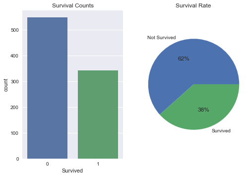

```python
plt.subplot(1,2,1)
sns.countplot(x='Survived',data=titanic_df)
plt.title('Survival Counts')

plt.subplot(1,2,2)
plt.pie(titanic_df.groupby('Survived')['Survived'].count(),labels=['Not Survived','Survived'],autopct='%1.0f%%')
plt.axis('equal')
plt.title('Survival Rate')
```

891名乘客中，只有38%的人生还，62%的人未能生还，下面就进一步探讨生还率可能与哪些因素有关

### 1.Pclass变量

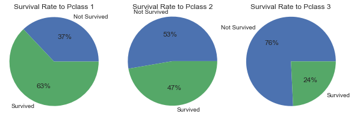

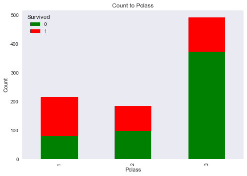

```python
plt.figure(figsize=(10,3))
plt.subplot(1,3,1)
pclass_1_df=titanic_df[titanic_df['Pclass']==1]
pclass_2_df=titanic_df[titanic_df['Pclass']==2]
pclass_3_df=titanic_df[titanic_df['Pclass']==3]
plt.pie([pclass_1_df[pclass_1_df['Survived']==0]['Survived'].count(),pclass_1_df[pclass_1_df['Survived']==1]['Survived'].count()],\
        labels=['Not Survived','Survived'],autopct='%1.0f%%')
plt.title('Survival Rate to Pclass 1')
plt.axis('equal')

plt.subplot(1,3,2)
plt.pie([pclass_2_df[pclass_2_df['Survived']==0]['Survived'].count(),pclass_2_df[pclass_2_df['Survived']==1]['Survived'].count()],\
        labels=['Not Survived','Survived'],autopct='%1.0f%%')
plt.title('Survival Rate to Pclass 2')
plt.axis('equal')

plt.subplot(1,3,3)
plt.pie([pclass_3_df[pclass_3_df['Survived']==0]['Survived'].count(),pclass_3_df[pclass_3_df['Survived']==1]['Survived'].count()],\
        labels=['Not Survived','Survived'],autopct='%1.0f%%')
plt.title('Survival Rate to Pclass 3')
plt.axis('equal')

titanic_df.groupby(['Pclass','Survived'])['Survived'].count().unstack().plot(kind='bar',stacked=True,color=['g','r'],grid=False)
plt.title('Count to Pclass')
plt.ylabel('Count')
```

一等舱的生还率为63%，二等舱为47%，三等舱为24%，表示舱级越高，生还率越高。

### 2.Sex变量

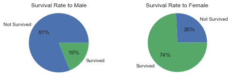

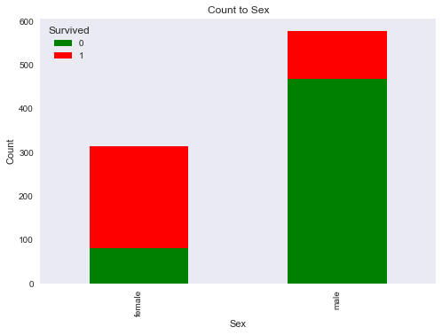

```python
plt.subplot(2,2,1)
sex_male_df=titanic_df[titanic_df['Sex']=='male']
sex_female_df=titanic_df[titanic_df['Sex']=='female']
plt.pie([sex_male_df[sex_male_df['Survived']==0]['Survived'].count(),sex_male_df[sex_male_df['Survived']==1]['Survived'].count()],\
       labels=['Not Survived','Survived'],autopct='%1.0f%%')
plt.title('Survival Rate to Male')
plt.axis('equal')

plt.subplot(2,2,2)
plt.pie([sex_female_df[sex_female_df['Survived']==0]['Survived'].count(),sex_female_df[sex_female_df['Survived']==1]['Survived'].\
         count()],labels=['Not Survived','Survived'],autopct='%1.0f%%')
plt.title('Survival Rate to Female')
plt.axis('equal')

titanic_df.groupby(['Sex','Survived'])['Survived'].count().unstack().plot(kind='bar',stacked=True,color=['g','r'],grid=False)
plt.title('Count to Sex')
plt.ylabel('Count')
```

男性生还率为19%,女性生还率为74%，可以看出女性生还率远远高于男性。

### 3.Age变量

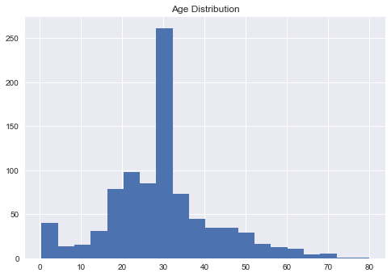

```python
plt.hist(titanic_df['Age'],bins=20)
plt.title('Age Distribution')
```

```python
bins=np.arange(0, 90, 10)
titanic_df['age_group']=pd.cut(titanic_df['Age'],bins)
titanic_df.groupby('age_group')['Survived'].mean()
```

```
age_group
(0, 10]     0.593750
(10, 20]    0.382609
(20, 30]    0.334152
(30, 40]    0.445161
(40, 50]    0.383721
(50, 60]    0.404762
(60, 70]    0.235294
(70, 80]    0.200000
Name: Survived, dtype: float64
```

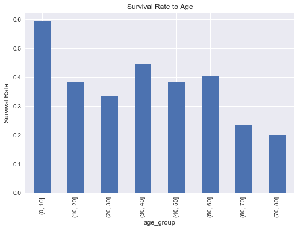

```python
titanic_df.groupby('age_group')['Survived'].mean().plot(kind='bar')
plt.title('Survival Rate to Age' )
plt.ylabel('Survival Rate')
```

### 4.SibSp变量

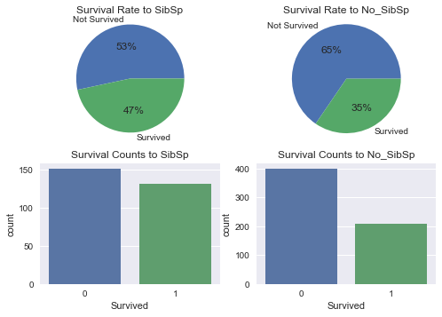

```python
sibsp_df=titanic_df[titanic['SibSp']!=0]
no_sibsp_df=titanic_df[titanic['SibSp']==0]
plt.subplot(2,2,1)
plt.pie([sibsp_df[sibsp_df['Survived']==0]['Survived'].count(),sibsp_df[sibsp_df['Survived']==1]['Survived'].count()],\
        labels=['Not Survived','Survived'],autopct='%1.0f%%')
plt.title('Survival Rate to SibSp')
plt.axis('equal')

plt.subplot(2,2,2)
plt.pie([no_sibsp_df[no_sibsp_df['Survived']==0]['Survived'].count(),no_sibsp_df[no_sibsp_df['Survived']==1]['Survived'].count()],\
        labels=['Not Survived','Survived'],autopct='%1.0f%%')
plt.title('Survival Rate to No_SibSp')
plt.axis('equal')

plt.subplot(2,2,3)
sns.countplot(x='Survived',data=sibsp_df)
plt.title('Survival Counts to SibSp')

plt.subplot(2,2,4)
sns.countplot(x='Survived',data=no_sibsp_df)
plt.title('Survival Counts to No_SibSp')
```

带有兄弟姐妹或者伴侣的乘客的生还率为47%，没有兄弟姐妹或者伴侣的乘客的生还率为35%，相较之下带有兄弟姐妹或者伴侣的乘客生还率要高一些。

### 5.Parch变量

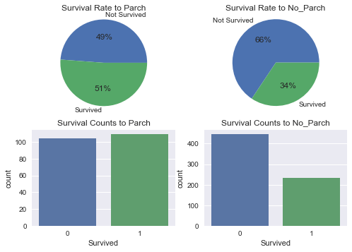

```python
parch_df=titanic_df[titanic['Parch']!=0]
no_parch_df=titanic_df[titanic['Parch']==0]
plt.subplot(2,2,1)
plt.pie([parch_df[parch_df['Survived']==0]['Survived'].count(),parch_df[parch_df['Survived']==1]['Survived'].count()],\
        labels=['Not Survived','Survived'],autopct='%1.0f%%')
plt.title('Survival Rate to Parch')
plt.axis('equal')

plt.subplot(2,2,2)
plt.pie([no_parch_df[no_parch_df['Survived']==0]['Survived'].count(),no_parch_df[no_parch_df['Survived']==1]['Survived'].count()],\
        labels=['Not Survived','Survived'],autopct='%1.0f%%')
plt.title('Survival Rate to No_Parch')
plt.axis('equal')

plt.subplot(2,2,3)
sns.countplot(x='Survived',data=parch_df)
plt.title('Survival Counts to Parch')

plt.subplot(2,2,4)
sns.countplot(x='Survived',data=no_parch_df)
plt.title('Survival Counts to No_Parch')
```

带有父母孩子的乘客的生还人数约为108，生还率为51%，没有父母孩子的乘客的生还人数约为240，生还率为34%，相较之下带有父母孩子的乘客生还率要高一些。

### 6.SibSp和Parch变量即独自一人的乘客和非独自一人的乘客

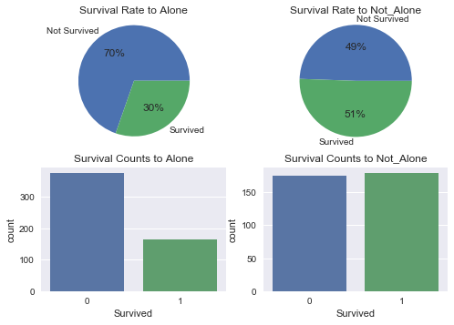

```python
alone_df=titanic_df[(titanic_df['SibSp']==0)&(titanic_df['Parch']==0)]
not_alone_df=titanic_df[(titanic_df['SibSp']!=0)|(titanic_df['Parch']!=0)]
plt.subplot(2,2,1)
plt.pie([alone_df[alone_df['Survived']==0]['Survived'].count(),alone_df[alone_df['Survived']==1]['Survived'].count()],\
       labels=['Not Survived','Survived'],autopct='%1.0f%%')
plt.title('Survival Rate to Alone')
plt.axis('equal')

plt.subplot(2,2,2)
plt.pie([not_alone_df[not_alone_df['Survived']==0]['Survived'].count(),not_alone_df[not_alone_df['Survived']==1]['Survived'].count()],\
       labels=['Not Survived','Survived'],autopct='%1.0f%%')
plt.title('Survival Rate to Not_Alone')
plt.axis('equal')

plt.subplot(2,2,3)
sns.countplot(x='Survived',data=alone_df)
plt.title('Survival Counts to Alone')
plt.subplot(2,2,4)
sns.countplot(x='Survived',data=not_alone_df)
plt.title('Survival Counts to Not_Alone')
```

独自一人的乘客生还人数为170左右，生还率为30%，非独自一人的乘客生还人数为180左右，生还率为51%，可以发现非独自一人的生还率较高。

### 7.Fare变量

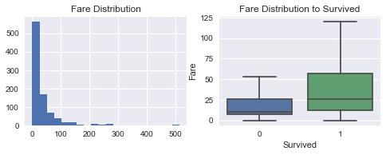

```python
plt.subplot(2,2,1)
plt.hist(titanic_df['Fare'],bins=20)
plt.title('Fare Distribution')

plt.subplot(2,2,2)
sns.boxplot(x='Survived',y='Fare',data=titanic_df,showfliers=False)
plt.title('Fare Distribution to Survived')
```

### 8.Embarked变量

```
(-1.1152445453600714,
 1.1007259494577988,
 -1.1176819858270148,
 1.1049298534646603)
```

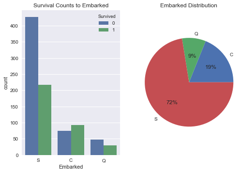

```python
plt.subplot(1,2,1)
sns.countplot(x='Embarked',hue='Survived',data=titanic_df)
plt.title('Survival Counts to Embarked')

plt.subplot(1,2,2)
plt.pie(titanic_df.groupby('Embarked')['Embarked'].count(),labels=['C','Q','S'],autopct='%1.0f%%')
plt.title('Embarked Distribution')
plt.axis('equal')
```

# 总结

1.船舱有三个级别，分别为1、2、3等级，其乘客数分别约为210，180，490人左右，其中一等舱的生还率为63%，二等舱为47%，三等舱为24%，由此可见船舱级别对生还率有一定的影响，舱级越高，生还率越高。这可能与其对应的‘VIP’服务有关，'VIP'乘客较普通乘客在同等情况下待遇更优先一下。

2.男女乘客数分别约为580、311，但男性生还率只有19%,女性生还率为74%，可以看出女性生还率远远高于男性。表明在此次事故中男性发挥了“女士优先，保护女性”的作用。

4.带有兄弟姐妹或者伴侣的乘客生还人数约为130，生还率为47%，没有兄弟姐妹或者伴侣的乘客生还人数约为210，生还率为35%，相较之下带有兄弟姐妹或者伴侣的乘客生还率要高一些。

5.带有父母孩子的乘客生还人数约为108，生还率为51%，没有父母孩子的乘客的生还人数约为240，生还率为34%，相较之下带有父母孩子的乘客生还率要高一些。 由4、5综合分析独自一人的乘客生还率为30%，非独自一人的乘客生还率为51%，可以发现非独自一人的生还率较高。可能原因是因为亲人的力量激发他们活下去的欲望以及亲人间的相互帮助与鼓励也起到了一定的关键作用。

7.乘客大多数是在S港口上船，S港口上船的生还人数也最多，其次为C，最低的为Q。

# 分析限制

在泰坦尼克号上有 2224 名乘客和船员但这次分析只分析了891名乘客的数据，是抽样数据，并且抽样方式不明确可能会对分析结果有一定的影响。

# 参考资料

网站 http://matplotlib.org/api/pyplot_api.html#matplotlib.pyplot.hist 画图 http://seaborn.pydata.org/api.html 画图 http://pandas.pydata.org/pandas-docs/stable/dsintro.html 函数调用 https://docs.python.org/2/library/functions.html 函数调用 微博 https://zhuanlan.zhihu.com/p/26888595 https://zhuanlan.zhihu.com/p/26440212